# week3_exercise

Wenke Zimmermann

2022-05-10

Segmentation of Trajectories

## Load the necessary libraries

```r
library(tidyverse)
library(lubridate)
library(SimilarityMeasures)
library(cowplot)
```

## Load Data Sabi

```r
sabi <- read_delim("sabi.csv",",")
```

## A) Specify a temporal windows v for in which to measure Euclidean distances

In the dataset, the sampling interval is 15 minutes. If we take a temporal window of 60 minutes, that would mean including 4 fixes. We need to calculate the following Euclidean distances (pos representing single location):

1. pos[n-2] to pos[n]
2. pos[n-1] to pos[n]
3. pos[n] to pos[n+1]
4. pos[n] to pos[n+2]

## B) Measure the distance from every point to every other point within this temporal window (v)

We use the formula for calculating the Euclidean distance in in combination with lead() and lag(). For example, to create the necessary offset of n-2, we use lag(x, 2). For each offset, we create one individual column.

```r
sabi <- sabi %>%
  mutate(
    nMinus2 = sqrt((lag(E,2)-E)^2+(lag(N,2)-N)^2),   # distance to pos -30 minutes
    nMinus1 = sqrt((lag(E,1)-E)^2+(lag(N,1)-N)^2),   # distance to pos -15 minutes
    nPlus1  = sqrt((E-lead(E,1))^2+(N-lead(N,1))^2), # distance to pos +15 mintues
    nPlus2  = sqrt((E-lead(E,2))^2+(N-lead(N,2))^2)  # distance to pos +30 minutes
  )
```

Now we want to calculate the mean distance of nMinus2, nMinus1, nPlus1, nPlus2 for each row. Since we want the mean value per Row, we have to explicitly specify this before mutate() with the function rowwise(). To remove this rowwise-grouping, we end the operation with ungroup().

Note that for the first two positions, we cannot calculate a stepMean since there is no Position n-2 for these positions. This is also true for the last to positions (lacking a position n+2).

```r
sabi <- sabi %>%
  rowwise() %>%
  mutate(
    stepMean = mean(c(nMinus2, nMinus1,nPlus1,nPlus2))
  ) %>%
  ungroup()
```

## C) Remove “static points”: These are points where the average distance is less than a given threshold. This segments the trajectory into subtrajectories

We can now determine if an animal is moving or not by specifying a threshold distance on stepMean. In our example, we use the mean value as a threshold: Positions with distances below this value are considered static.

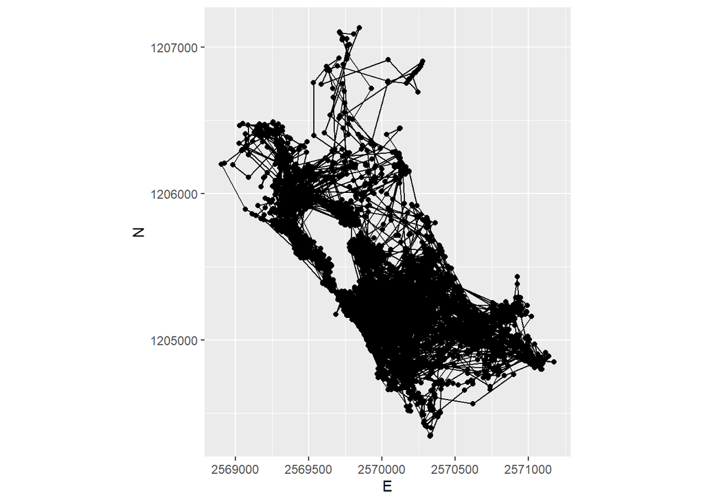

```r
sabi <- sabi %>%
  ungroup() %>%
  mutate(static = stepMean < mean(stepMean, na.rm = TRUE))

sabi_filter <- sabi %>%
  filter(!static)

sabi_filter%>%
  ggplot(aes(E, N)) +
  geom_path() +
  geom_point() +
  coord_fixed() +
  theme(legend.position = "bottom")
```

## D) Now remove short subtrajectories: These are trajectories with a short duration (whereas “short” is tbd)

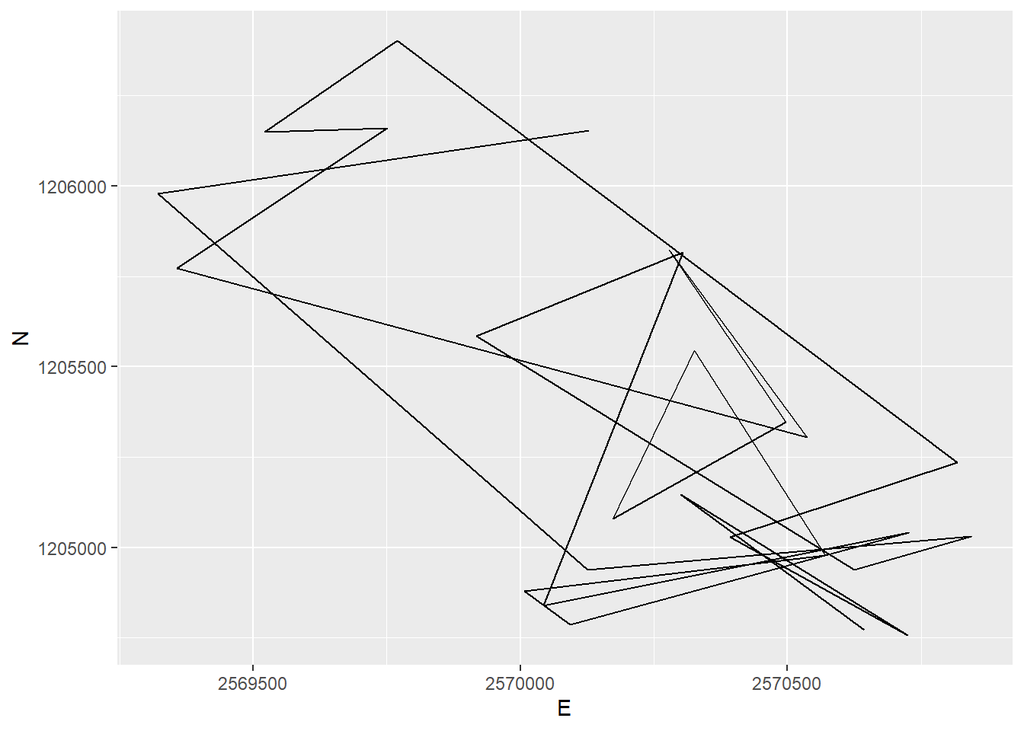

```r
ggplot()+
  geom_path(aes(E,N), sabi_filter %>% filter(stepMean > 500))
```

```r
#Grafik ist falsch, aber ohne weitere Fehlersuche mal zur richtigen Aufgabenstellung übergegangen
```

## Task 1:Segmentation

# Load Data

```r
caro <- read_delim("caro60.csv",",")
```